# MergeSort (Pengurutan Gabungan)

Permasalahan sorting akan lebih mudah dilaksanakan jika hanya terdapat satu elemen saja yang akan diurutkan. Jika hanya terdapat satu elemen dalam sebuah list data, maka data tersebut otomatis sudah dalam keadaan terurut.

**Algoritma Merge Sort** adalah algoritma bagi-dan-taklukkan yang mengurutkan sebuah array dengan terlebih dahulu memecahnya menjadi array yang lebih kecil, lalu menyusun kembali array tersebut dengan cara yang benar sehingga menjadi terurut.

Merge Sort merupakan algoritma pengurutan dengan konsep rekursif, yang terdiri dari dua tahapan utama, yaitu

1. Splitting atau proses divide
2. Merging

**Cara kerjanya:**

1. Bagilah array yang belum diurutkan menjadi dua sub-array, dengan ukuran setengah dari ukuran aslinya.
2. Lanjutkan membagi sub-array selama bagian array saat ini memiliki lebih dari satu elemen.
3. Gabungkan dua sub-array dengan selalu menempatkan nilai terendah terlebih dahulu.
4. Terus gabungkan hingga tidak ada sub-array yang tersisa.

#### **Divide**

Proses Splitting atau Divide adalah proses yang membagi list data menjadi dua buah bagian. Proses splitting data list ini dilakukan secara terus menerus, sampai hanya tersisa satu elemen saja didalam list. **Top-Down Process** Contoh proses ini dapat dilihat pada Gambar 1 berikut :

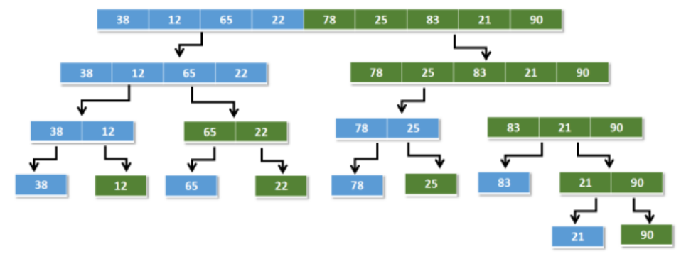

Pada Gambar 1 tersebut ditunjukkan bahwa data yang terdiri dari sembilan elemen, yaitu [38, 12, 65, 22, 78, 25, 83, 21, 90]. Pada proses divide ini, data dibagi menjadi dua bagian kiri (warna biru) dan kanan (warna hijau), sehingga data bagian kiri terdiri dari empat elemen, yaitu [38, 12, 65, 22], sedangkan bagian kanan menjadi [78, 25, 83, 21, 90]. Proses ini dilakukan terus menerus, sehingga terdapat data yang hanya memiliki satu elemen saja, yaitu [38], [12], [65], [22], [78], [25], [83], [21], dan [90].

Berikut algoritma untuk membagi data menjadi dua bagian, kiri dan kanan.

mid = len(data) // 2

leftData = data[:mid]

rightData = data[mid:]

#### **Merge**

Proses Merge ini menggabungkan data-data yang sudah terbagi pada Tahap pertama (divide/split). Proses merge ini juga melibatkan proses membandingkan data antara list yang akan digabung. Sehingga, setelah proses merge, data pada list akan terurut. Proses ini akan dilakukan terus menerus, sehingga tidak ada lagi list yang akan digabungkan. Tahapan merge ini adalah **Bottom - up process**

Contoh proses merge dapat dilihat pada Gambar 2 berikut

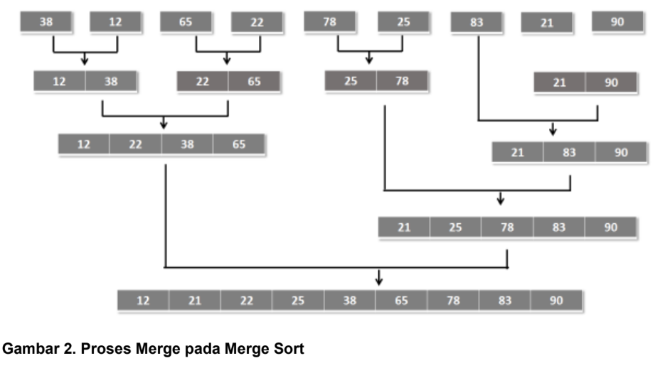

Pada Gambar tersebut ditunjukka, pada proses merging, data yang terdapat pada list yang akan digabung, dibandingkan terlebih dahulu, jika data lebih kecil, maka data tersebut akan diletakkan pada indeks yang lebih rendah, sehingga setelah proses merging selesai, data sudah dalam keadaan terurut.

Berikut adalah code untuk algoritma pengurutan Merge Sort, dan contoh pemanggilan fungsi merge sort ini.

```python
def merge_sort_asc(a_list):
    print("Splitting ", a_list)
    if len(a_list) > 1:
        mid = len(a_list) // 2
        left_half = a_list[:mid]
        right_half = a_list[mid:]
        merge_sort_asc(left_half)
        merge_sort_asc(right_half)

        i = 0
        j = 0
        k = 0

        while i < len(left_half) and j < len(right_half):
            if left_half[i] < right_half[j]:  # ASCENDING
                a_list[k] = left_half[i]
                i += 1
            else:
                a_list[k] = right_half[j]
                j += 1
            k += 1

        while i < len(left_half):
            a_list[k] = left_half[i]
            i += 1
            k += 1

        while j < len(right_half):
            a_list[k] = right_half[j]
            j += 1
            k += 1

    print("Merging ", a_list)


a = [38,12,65,22,78,25,83,21,90]
merge_sort_asc(a)
print("Hasil Ascending:", a)
```

```
Splitting  [38, 12, 65, 22, 78, 25, 83, 21, 90]
Splitting  [38, 12, 65, 22]
Splitting  [38, 12]
Splitting  [38]
Merging  [38]
Splitting  [12]
Merging  [12]
Merging  [12, 38]
Splitting  [65, 22]
Splitting  [65]
Merging  [65]
Splitting  [22]
Merging  [22]
Merging  [22, 65]
Merging  [12, 22, 38, 65]
Splitting  [78, 25, 83, 21, 90]
Splitting  [78, 25]
Splitting  [78]
Merging  [78]
Splitting  [25]
Merging  [25]
Merging  [25, 78]
Splitting  [83, 21, 90]
Splitting  [83]
Merging  [83]
Splitting  [21, 90]
Splitting  [21]
Merging  [21]
Splitting  [90]
Merging  [90]
Merging  [21, 90]
Merging  [21, 83, 90]
Merging  [21, 25, 78, 83, 90]
Merging  [12, 21, 22, 25, 38, 65, 78, 83, 90]
Hasil Ascending: [12, 21, 22, 25, 38, 65, 78, 83, 90]
```

```python
def merge_sort_desc(a_list):
    print("Splitting ", a_list)
    if len(a_list) > 1:
        mid = len(a_list) // 2
        left_half = a_list[:mid]
        right_half = a_list[mid:]

        merge_sort_desc(left_half)
        merge_sort_desc(right_half)

        i = 0
        j = 0
        k = 0

        while i < len(left_half) and j < len(right_half):
            if left_half[i] > right_half[j]:  # DESCENDING
                a_list[k] = left_half[i]
                i += 1
            else:
                a_list[k] = right_half[j]
                j += 1
            k += 1

        while i < len(left_half):
            a_list[k] = left_half[i]
            i += 1
            k += 1

        while j < len(right_half):
            a_list[k] = right_half[j]
            j += 1
            k += 1

    print("Merging ", a_list)


a = [38,12,65,22,78,25,83,21,90]
merge_sort_desc(a)
print("Hasil Descending:", a)
```

```
Splitting  [38, 12, 65, 22, 78, 25, 83, 21, 90]
Splitting  [38, 12, 65, 22]
Splitting  [38, 12]
Splitting  [38]
Merging  [38]
Splitting  [12]
Merging  [12]
Merging  [38, 12]
Splitting  [65, 22]
Splitting  [65]
Merging  [65]
Splitting  [22]
Merging  [22]
Merging  [65, 22]
Merging  [65, 38, 22, 12]
Splitting  [78, 25, 83, 21, 90]
Splitting  [78, 25]
Splitting  [78]
Merging  [78]
Splitting  [25]
Merging  [25]
Merging  [78, 25]
Splitting  [83, 21, 90]
Splitting  [83]
Merging  [83]
Splitting  [21, 90]
Splitting  [21]
Merging  [21]
Splitting  [90]
Merging  [90]
Merging  [90, 21]
Merging  [90, 83, 21]
Merging  [90, 83, 78, 25, 21]
Merging  [90, 83, 78, 65, 38, 25, 22, 21, 12]
Hasil Descending: [90, 83, 78, 65, 38, 25, 22, 21, 12]
```

#### Panduan Langkah demi Langkah

Mari kita coba melakukan pengurutan secara manual, hanya untuk mendapatkan pemahaman yang lebih baik tentang cara kerja Merge Sort sebelum benar-benar mengimplementasikannya dalam bahasa pemrograman.

**Langkah 1**: Kita mulai dengan array yang belum diurutkan, dan kita tahu bahwa array tersebut akan terbagi menjadi dua hingga sub-array hanya terdiri dari satu elemen. Fungsi Merge Sort memanggil dirinya sendiri dua kali, sekali untuk setiap setengah dari array. Itu berarti bahwa sub-array pertama akan terbagi menjadi bagian-bagian terkecil terlebih dahulu.

[ 12, 8, 9, 3, 11, 5, 4] [ 12, 8, 9] [ 3, 11, 5, 4] [ 12] [ 8, 9] [ 3, 11, 5, 4] [ 12] [ 8] [ 9] [ 3, 11, 5, 4]

**Langkah 2**: Pemisahan sub-array pertama telah selesai, dan sekarang saatnya untuk menggabungkan. 8 dan 9 adalah dua elemen pertama yang akan digabungkan. 8 adalah nilai terendah, jadi nilainya berada sebelum 9 dalam sub-array gabungan pertama.

[ 12] [ 8, 9] [ 3, 11, 5, 4]

**Langkah 3**: Sub-array berikutnya yang akan digabungkan adalah [ 12] dan [ 8, 9]. Nilai dalam kedua array dibandingkan dari awal. 8 lebih rendah dari 12, jadi 8 didahulukan, dan 9 juga lebih rendah dari 12.

[ 8, 9, 12] [ 3, 11, 5, 4]

**Langkah 4**: Sekarang sub-array besar kedua dibagi secara rekursif.

[ 8, 9, 12] [ 3, 11, 5, 4] [ 8, 9, 12] [ 3, 11] [ 5, 4] [ 8, 9, 12] [ 3] [ 11] [ 5, 4]

**Langkah 5**: Angka 3 dan 11 digabungkan kembali dalam urutan yang sama seperti yang ditampilkan karena 3 lebih rendah dari 11.

[ 8, 9, 12] [ 3, 11] [ 5, 4]

**Langkah 6**: Sub-array dengan nilai 5 dan 4 dipisahkan, kemudian digabungkan sehingga 4 berada sebelum 5.

[ 8, 9, 12] [ 3, 11] [ 5] [ 4] [ 8, 9, 12] [ 3, 11] [ 4, 5]

**Langkah 7**: Kedua sub-array di sebelah kanan digabungkan. Perbandingan dilakukan untuk membuat elemen dalam array gabungan yang baru:

3 lebih kecil dari 4

4 lebih kecil dari 11

5 lebih kecil dari 11

11 adalah nilai terakhir yang tersisa

[ 8, 9, 12] [ 3, 4, 5, 11]

**Langkah 8**: Dua sub-array terakhir yang tersisa digabungkan. Mari kita lihat bagaimana perbandingan dilakukan secara lebih detail untuk membuat array gabungan dan terurut yang baru:

3 lebih kecil dari 8:

Before [ 8, 9, 12] [ 3, 4, 5, 11]

After: [ 3, 8, 9, 12] [ 4, 5, 11]

**Langkah 9**: 4 lebih rendah dari 8:

Before [ 3, 8, 9, 12] [ 4, 5, 11] After: [ 3, 4, 8, 9, 12] [ 5, 11] Langkah 10: 5 lebih rendah dari 8:

Before [ 3, 4, 8, 9, 12] [ 5, 11] After: [ 3, 4, 5, 8, 9, 12] [ 11] Langkah 11: 8 dan 9 lebih rendah dari 11:

Before [ 3, 4, 5, 8, 9, 12] [ 11] After: [ 3, 4, 5, 8, 9, 12] [ 11] Langkah 12: 11 lebih rendah dari 12:

Before [ 3, 4, 5, 8, 9, 12] [ 11] After: [ 3, 4, 5, 8, 9, 11, 12] Proses penyortiran selesai!

#### Implementasi Pengurutan Gabungan (Merge Sort)

Untuk mengimplementasikan algoritma Merge Sort, kita membutuhkan:

1. Sebuah array berisi nilai-nilai yang perlu diurutkan.
2. Sebuah fungsi yang menerima sebuah array, membaginya menjadi dua, dan memanggil dirinya sendiri dengan setiap bagian dari array tersebut sehingga array tersebut dibagi lagi dan lagi secara rekursif, sampai sebuah sub-array hanya terdiri dari satu nilai.
3. Fungsi lain yang menggabungkan kembali sub-array menjadi satu dalam urutan yang sudah diurutkan. Kode yang dihasilkan akan terlihat seperti ini:

```python
def mergeSort(arr):
    if len(arr) <= 1:
        return arr

    mid = len(arr) // 2
    leftHalf = arr[:mid]
    rightHalf = arr[mid:]

    sortedLeft = mergeSort(leftHalf)
    sortedRight = mergeSort(rightHalf)

    return merge(sortedLeft, sortedRight)

def merge(left, right):
    result = []
    i = j = 0

    while i < len(left) and j < len(right):
        if left[i] < right[j]:
            result.append(left[i])
            i += 1
        else:
            result.append(right[j])
            j += 1

    result.extend(left[i:])
    result.extend(right[j:])

    return result

unsortedArr = [3, 7, 6, -10, 15, 23.5, 55, -13]
sortedArr = mergeSort(unsortedArr)
print("Sorted array:", sortedArr)
```

```
Sorted array: [-13, -10, 3, 6, 7, 15, 23.5, 55]
```